# Shapefiles

O pacote **measurements** permite converter latitude e longitude em radianos (graus, minutos, segundos) para decimal ou vice-versa.

Por exemplo o bairro do Rio Pequeno em São Paulo latitude e longitude decimal: -23.5665987,-46.7586146. Se quiséssemos converter -23.5665987 para coordenadas em radianos faríamos:

```r
minutos = 60*0.5665987
segundos = 60*(minutos-33)
print(minutos)
```

```
## [1] 33.99592
```

```r
print(segundos)
```

```
## [1] 59.75532
```

Assim -23.5665987 corresponderia a: **-23 33’ 59.75532’’**.

Usando o pacote **measurements**:

```r
library(measurements)
conv_unit(x = -23.5665987, from = "dec_deg", to = "deg_min_sec")
```

```
## [1] "-23 33 59.7553199999966"
```

O inverso, converter **-23 33’ 59.75532’’** para decimal:

```r
23 + 33/60 + 59.75532/(60*60)
```

```
## [1] 23.5666
```

Ou usando a biblioteca:

```r
conv_unit(x = "-23 33 59.75532", from = "deg_min_sec", to = "dec_deg")
```

```
## [1] "-23.5665987"
```

Para abertura do shapefile usamos o pacote rgdal. Como exemplo baixei um shapefile do site https://www.ibge.gov.br/geociencias/organizacao-do-territorio/malhas-territoriais/15774-malhas.html em Downloads, municipio_2020, Minas Gerais.

Os arquivos shp, dbf, shx e prj devem estar em um único diretório e com o mesmo nome em cada extensão. Exemplo, no diretório **MG_Municipios** vamos ler os arquivos MG.shp, MG.dbf, MG.shx e MG.prj:

```r
library(rgdal)
shapefile_MG <- readOGR(dsn = "data/shapefiles/MG_Municipios", layer = "MG")
```

Lembrando que:

- shp: geometria, isto é, os polígonos do mapa
- dbf: base de dados
- shx: relaciona os arquivos shp e dbf
- prj: sistema de projeção geográfica

Para acessar os dados usamos o arroba e depois o nome da variável:

```r
head(shapefile_MG@data$NM_MUN)
```

```
## [1] Abadia dos Dourados Abaeté              Abre Campo
## [4] Acaiaca             Açucena             Água Boa
## 853 Levels: Abadia dos Dourados Abaeté Abre Campo Acaiaca Açucena ... Wenceslau Braz
```

Mapa:

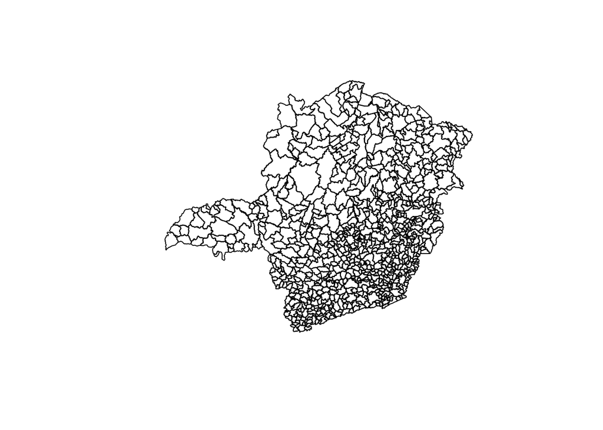

```r
plot(shapefile_MG)
```

```r
library(raster)
raster::area(shapefile_MG)
```

```
##   [1]   880461217  1817066894   470550977   101885989   815421880  1320343653
##   [7]   492166785   232091152   820078973  1256607300  1348912968   649679590
##  [13]   161355617    58009982   510249712   850445503   130814558  2294425878
##  [19]   166972386   460685472   362009660   103690352   518052673   278174423
##  [25]   599443309   374008487   136185930   469396325   695672331  1005284626
##  [31]   185210812   529914993   787060643    83802332   187538125   106608227
##  [37]  2236278987  2729777209    89420025   303792627   294353521   173893703
##  [43]   245522063  1164061570   162875113   509873451   283123533   159377956
##  [49]   243328834  5279419036   158890572  1836915488  1254831615   750553697
##  [55]   556266422  1455818688   483788757    47266037   340139831   198312855
##  [61]   759185778   383628012    82069746   109143057   393086160   331353588
##  [67]   334909262   365923042   587105987   427803237   488756118   343883535
##  [73]   283535421   140082345   458947689   860668999   503769912  3206756747
##  [79]  1213545586   412020831   208349406   195611001   592288558   229844880
##  [85]   705046139   301865263  1850487362  3936455062   301108037   334088699
```

[output cut: 128 more lines]

Qual é o municipio 853?

```r
shapefile_MG@data$NM_MUN[853]
```

```
## [1] Wenceslau Braz
## 853 Levels: Abadia dos Dourados Abaeté Abre Campo Acaiaca Açucena ... Wenceslau Braz
```

Qual a área de Wenceslau Braz?

```r
raster::area(shapefile_MG)[853]
```

```
## [1] 102487354
```

Podemos criar uma nova coluna com a área em km:

```r
shapefile_MG$data$area_em_km = raster::area(shapefile_MG)/1000000
```

Área de Wenceslau Braz em km:

```r
shapefile_MG$data$area_em_km[853]
```

```
## [1] 102.4874
```

Vamos ler o shapefile da malha municipal de são paulo baixado de: https://www.ibge.gov.br/geociencias/organizacao-do-territorio/malhas-territoriais.html

```r
library(rgdal)
shapefile_SP <- readOGR(dsn = "data/shapefiles/SP_Municipios", layer = "SP")
```

Dado o arquivo sp.csv que contém pib, população e idh dos munícípios de são paulo:

```r
sp = read.csv("data/sp.csv")
```

Juntando o arquivo csv com o shapefile:

```r
shapefile_SP <- merge(x = shapefile_SP,
                      y = sp,
                      by.x = "CD_MUN",
                      by.y = "codigo")
```

Exportanto o shapefile modificado:

```r
writeOGR(obj = shapefile_SP,
         layer = "SP_mudado",
         overwrite_layer=TRUE,
         driver = "ESRI Shapefile",
         dsn = "/tmp/shapefile_SP_modificado")
```

Podemos acessar o dataframe que está dentro do objeto shapefile com **@data**:

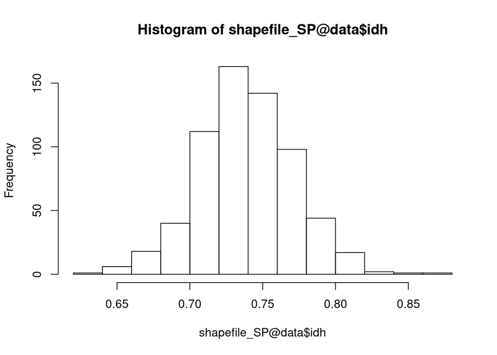

```r
hist(shapefile_SP@data$idh)
```